# MCMD Analysis of Nutritional Powder Recipes

Truong Ngan Giang

2025-12-12

# Executive Summary

This report presents a **Multi-Criteria Decision Making (MCDM)** analysis of four sweet potato recipes (S-A, S-B, S-C, S-D) using three different methodologies. The analysis aims to identify the most nutritionally optimal recipe based on multiple nutritional criteria.

# 1. Introduction

## 1.1 Background

This analysis compares four different nutritional powder recipes made with dried vegetables and fruits to determine which offers the optimal nutritional profile based on multiple criteria.

## 1.2 Methods Overview

Three MCDM methods are employed:

1. **TOPSIS** (Technique for Order Preference by Similarity to Ideal Solution)
2. **PCA-based Ranking** (Principal Component Analysis)
3. **Weighted Sum Scoring** (Normalized additive model)

## 1.3 Data Description

# 2. Data Preparation

```r
# Nutritional data for nutritional powder recipes
nutrition_data <- data.frame(
  Recipe = c("S-A", "S-B", "S-C", "S-D"),
  Water = c(6.07, 6.06, 5.98, 5.88),          # g/100g
  Fiber = c(0.48, 0.48, 0.49, 0.50),          # g/100g
  Protein = c(3.20, 3.47, 3.27, 3.19),        # g/100g
  Sugar = c(37.67, 35.62, 36.69, 36.10),      # g/100g
  Vitamin_C = c(71.89, 73.40, 74.25, 70.13),  # mg/kg
  Vitamin_B1 = c(0.28, 0.28, 0.28, 0.30),     # mg/kg
  Calcium = c(802, 784, 742, 867),            # mg/kg
  Phosphorus = c(0.85, 0.85, 0.81, 0.83),     # mg/kg
  Iron = c(15.08, 16.46, 14.03, 13.40),       # mg/kg
  Potassium = c(2868, 2961, 2612, 2733),      # mg/kg
  Magnesium = c(317, 336, 354, 320),          # mg/kg
  Sodium = c(713, 736, 630, 695)              # mg/kg
)

# Criteria classification
benefit_criteria <- c("Fiber", "Protein", "Vitamin_C", "Vitamin_B1", "Calcium",
                      "Phosphorus", "Iron", "Potassium", "Magnesium")
cost_criteria <- c("Water", "Sugar", "Sodium")

# Display the data
kable(nutrition_data,
      caption = "Nutritional Composition of Sweet Potato Recipes",
      align = 'c',
      format = 'html') %>%
  kable_styling(bootstrap_options = c("striped", "hover", "condensed"),
                full_width = FALSE,
                position = "center") %>%
  column_spec(1, bold = TRUE) %>%
  add_header_above(c(" " = 1, "Macronutrients (g)" = 4, "Vitamins (mg)" = 2,
                     "Minerals (mg)" = 6)) %>%
  footnote(general = "Units: Water, Fiber, Protein, Sugar (g/100g); Vitamin C, B1, Calcium, Phosphorus, Iron, Potassium, Magnesium, Sodium (mg/kg)")
```

Nutritional Composition of Sweet Potato Recipes

| Recipe | Macronutrients (g) Water | Macronutrients (g) Fiber | Macronutrients (g) Protein | Macronutrients (g) Sugar | Vitamins (mg) Vitamin_C | Vitamins (mg) Vitamin_B1 | Minerals (mg) Calcium | Minerals (mg) Phosphorus | Minerals (mg) Iron | Minerals (mg) Potassium | Minerals (mg) Magnesium | Minerals (mg) Sodium |
| --- | --- | --- | --- | --- | --- | --- | --- | --- | --- | --- | --- | --- |
| S-A | 6.07 | 0.48 | 3.20 | 37.67 | 71.89 | 0.28 | 802 | 0.85 | 15.08 | 2868 | 317 | 713 |
| S-B | 6.06 | 0.48 | 3.47 | 35.62 | 73.40 | 0.28 | 784 | 0.85 | 16.46 | 2961 | 336 | 736 |
| S-C | 5.98 | 0.49 | 3.27 | 36.69 | 74.25 | 0.28 | 742 | 0.81 | 14.03 | 2612 | 354 | 630 |
| S-D | 5.88 | 0.50 | 3.19 | 36.10 | 70.13 | 0.30 | 867 | 0.83 | 13.40 | 2733 | 320 | 695 |

Note:  
Units: Water, Fiber, Protein, Sugar (g/100g); Vitamin C, B1, Calcium, Phosphorus, Iron, Potassium, Magnesium, Sodium (mg/kg)

# 3. TOPSIS Analysis

## 3.1 Method Description

TOPSIS identifies the alternative that is closest to the ideal solution and farthest from the negative-ideal solution.

```r
# TOPSIS function
topsis <- function(data, benefits, costs, weights = NULL) {
  if (is.null(weights)) {
    weights <- rep(1, ncol(data))
  }

  # Step 1: Normalize the decision matrix
  normalized <- apply(data, 2, function(x) x / sqrt(sum(x^2)))

  # Step 2: Apply weights
  weighted <- normalized * weights

  # Step 3: Determine ideal solutions
  ideal_best <- apply(weighted[, benefits, drop = FALSE], 2, max)
  ideal_worst <- apply(weighted[, benefits, drop = FALSE], 2, min)

  ideal_best <- c(ideal_best, apply(weighted[, costs, drop = FALSE], 2, min))
  ideal_worst <- c(ideal_worst, apply(weighted[, costs, drop = FALSE], 2, max))

  # Step 4: Calculate distances
  dist_best <- sqrt(rowSums((t(t(weighted) - ideal_best))^2))
  dist_worst <- sqrt(rowSums((t(t(weighted) - ideal_worst))^2))

  # Step 5: Calculate TOPSIS scores
  score <- dist_worst / (dist_best + dist_worst)

  return(score)
}
# Apply TOPSIS
scores <- topsis(nutrition_data[, -1], benefit_criteria, cost_criteria)
topsis_results <- data.frame(
  Recipe = nutrition_data$Recipe,
  TOPSIS_Score = round(scores, 4)
)
topsis_results <- topsis_results[order(-topsis_results$TOPSIS_Score), ]
topsis_results$Rank <- 1:nrow(topsis_results)
```

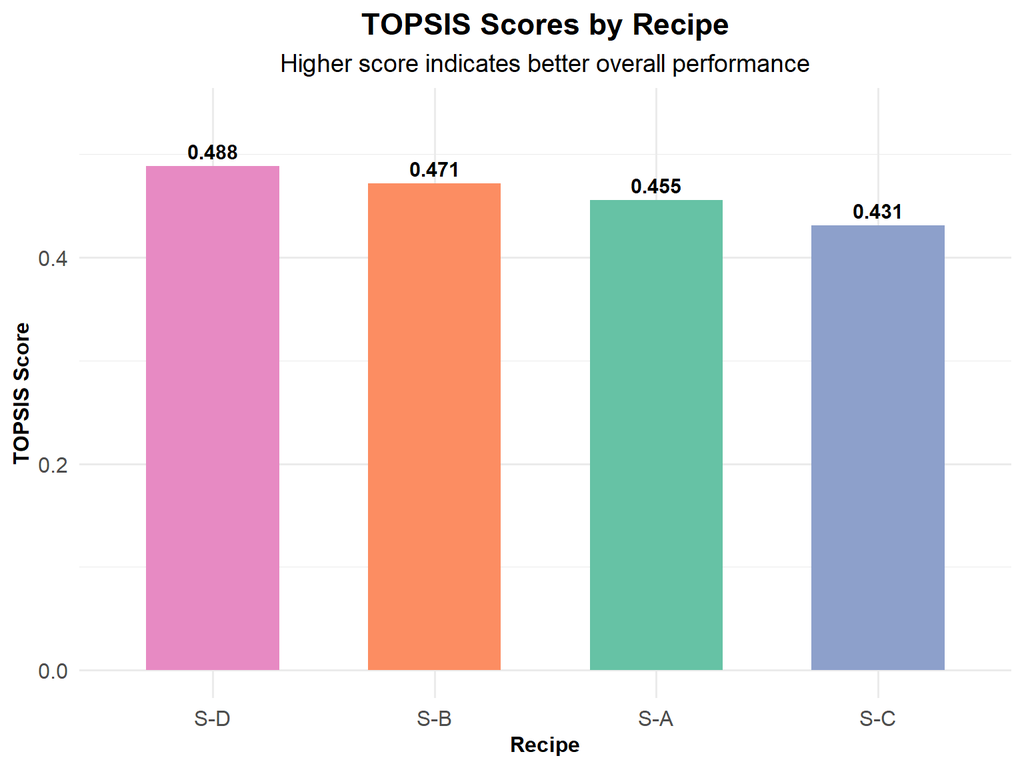

TOPSIS Scores Visualization

```r
# Create bar plot of TOPSIS scores
ggplot(topsis_results, aes(x = reorder(Recipe, -TOPSIS_Score), y = TOPSIS_Score,
                           fill = Recipe)) +
  geom_bar(stat = "identity", width = 0.6) +
  geom_text(aes(label = round(TOPSIS_Score, 3)),
            vjust = -0.5, size = 4, fontface = "bold") +
  scale_fill_brewer(palette = "Set2") +
  labs(x = "Recipe", y = "TOPSIS Score",
       title = "TOPSIS Scores by Recipe",
       subtitle = "Higher score indicates better overall performance") +
  theme_minimal(base_size = 14) +
  theme(legend.position = "none",
        plot.title = element_text(face = "bold", hjust = 0.5),
        plot.subtitle = element_text(hjust = 0.5),
        axis.text = element_text(size = 12),
        axis.title = element_text(size = 12, face = "bold")) +
  ylim(0, max(topsis_results$TOPSIS_Score) * 1.1)
```

**Interpretation**: Recipe **S-D** achieves the highest TOPSIS score (0.488), indicating it has the most balanced nutritional profile - closest to the ideal solution across all criteria.

# 4. PCA-based Ranking

## 4.1 Method Description

Principal Component Analysis reduces dimensionality while preserving variance, allowing ranking based on underlying multivariate patterns. This practice identifies the recipe that best represents the major patterns of variation in the nutritional data, which may correlate with a unique or dominant nutritional profile.

```r
# Prepare data for PCA
pca_data <- nutrition_data[, -1]
rownames(pca_data) <- nutrition_data$Recipe

# Perform PCA
pca_result <- prcomp(pca_data, scale. = TRUE)

# Calculate scores based on first two principal components
pca_scores <- pca_result$x[, 1:2]
overall_pca <- rowSums(pca_scores * summary(pca_result)$importance[2, 1:2])

# Create ranking
pca_ranking <- data.frame(
  Recipe = nutrition_data$Recipe,
  PCA_Score = round(overall_pca, 4)
)
pca_ranking <- pca_ranking[order(-pca_ranking$PCA_Score), ]
pca_ranking$Rank <- 1:nrow(pca_ranking)
```

```r
# Display PCA results
kable(pca_ranking,
      caption = "PCA-based Ranking Results",
      col.names = c("Recipe", "PCA Score", "Rank"),
      align = 'c')
```

PCA-based Ranking Results

|  | Recipe | PCA Score | Rank |
| --- | --- | --- | --- |
| S-D | S-D | 1.5867 | 1 |
| S-A | S-A | -0.0054 | 2 |
| S-B | S-B | -0.7821 | 3 |
| S-C | S-C | -1.1067 | 4 |

```r
# Variance explained
variance_df <- data.frame(
  PC = paste0("PC", 1:length(pca_result$sdev)),
  Variance_Explained = round(summary(pca_result)$importance[2, ], 4),
  Cumulative_Variance = round(summary(pca_result)$importance[3, ], 4)
)

kable(variance_df,
      caption = "PCA Variance Explained",
      align = 'c') %>%
  kable_styling(bootstrap_options = c("striped", "hover"),
                full_width = FALSE,
                position = "center") %>%
  column_spec(1, bold = TRUE)
```

PCA Variance Explained

|  | PC | Variance_Explained | Cumulative_Variance |
| --- | --- | --- | --- |
| PC1 | PC1 | 0.4878 | 0.4878 |
| PC2 | PC2 | 0.3529 | 0.8408 |
| PC3 | PC3 | 0.1592 | 1.0000 |
| PC4 | PC4 | 0.0000 | 1.0000 |

# 5. Weighted Sum Scoring

## 5.1 Method Description

A simple additive model where each criterion is normalized and summed with equal weights.

```r
# Create scoring data frame
weighted_scores <- data.frame(Recipe = nutrition_data$Recipe)

# Normalize and score benefit criteria (higher is better)
for(crit in benefit_criteria) {
  min_val <- min(nutrition_data[[crit]])
  max_val <- max(nutrition_data[[crit]])
  weighted_scores[[crit]] <- (nutrition_data[[crit]] - min_val) / (max_val - min_val)
}

# Normalize and reverse score cost criteria (reverse so higher is better)
for(crit in cost_criteria) {
  min_val <- min(nutrition_data[[crit]])
  max_val <- max(nutrition_data[[crit]])
  weighted_scores[[crit]] <- 1 - ((nutrition_data[[crit]] - min_val) / (max_val - min_val))
}

# Calculate total score (equal weights assumed)
weighted_scores$Total_Score <- round(rowSums(weighted_scores[, -1]), 4)
weighted_ranking <- weighted_scores[order(-weighted_scores$Total_Score),
                                    c("Recipe", "Total_Score")]
weighted_ranking$Rank <- 1:nrow(weighted_ranking)
```

```r
# Display weighted sum results
kable(weighted_ranking,
      caption = "Weighted Sum Scoring Results",
      col.names = c("Recipe", "Total Score", "Rank"),
      align = 'c')
```

Weighted Sum Scoring Results

|  | Recipe | Total Score | Rank |
| --- | --- | --- | --- |
| 2 | S-B | 6.6958 | 1 |
| 4 | S-D | 6.0804 | 2 |
| 3 | S-C | 4.9433 | 3 |
| 1 | S-A | 3.4424 | 4 |

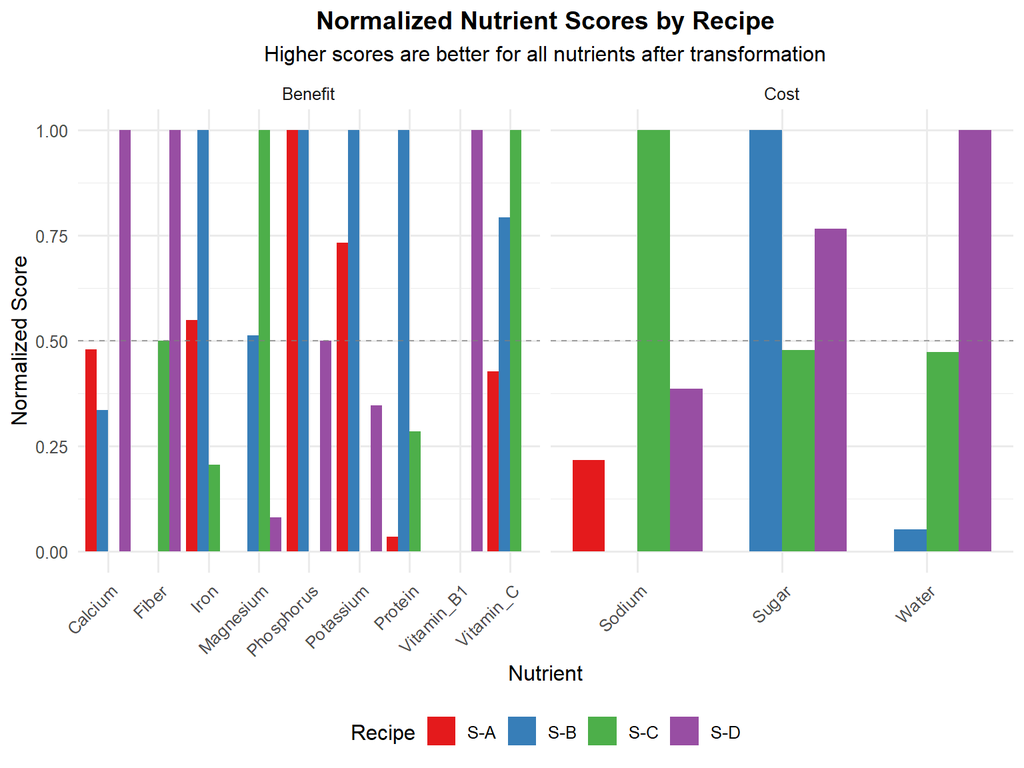

Normalized Scores by Nutrient

```r
# Create detailed view of normalized scores
normalized_long <- weighted_scores %>%
  pivot_longer(cols = -Recipe, names_to = "Nutrient", values_to = "Score") %>%
  filter(Nutrient != "Total_Score")

# Separate benefit and cost criteria
normalized_long$Type <- ifelse(normalized_long$Nutrient %in% benefit_criteria,
                               "Benefit", "Cost")

ggplot(normalized_long, aes(x = Nutrient, y = Score, fill = Recipe)) +
  geom_bar(stat = "identity", position = "dodge") +
  facet_wrap(~Type, scales = "free_x") +
  scale_fill_brewer(palette = "Set1") +
  labs(x = "Nutrient", y = "Normalized Score",
       title = "Normalized Nutrient Scores by Recipe",
       subtitle = "Higher scores are better for all nutrients after transformation") +
  theme_minimal(base_size = 12) +
  theme(axis.text.x = element_text(angle = 45, hjust = 1),
        plot.title = element_text(face = "bold", hjust = 0.5),
        plot.subtitle = element_text(hjust = 0.5),
        legend.position = "bottom") +
  geom_hline(yintercept = 0.5, linetype = "dashed", color = "gray50", alpha = 0.7)
```

**Interpretation**: Recipe **S-B** achieves the highest weighted sum score (6.6958), indicating it performs best when nutrients are considered independently with equal importance. This suggests S-B has strong individual nutrient values.

# 6. Comparative Analysis

```r
# Combine results from all methods
comparison <- data.frame(
  Recipe = topsis_results$Recipe,
  TOPSIS_Score = topsis_results$TOPSIS_Score,
  TOPSIS_Rank = topsis_results$Rank,
  PCA_Score = pca_ranking$PCA_Score[match(topsis_results$Recipe, pca_ranking$Recipe)],
  PCA_Rank = pca_ranking$Rank[match(topsis_results$Recipe, pca_ranking$Recipe)],
  WS_Score = weighted_ranking$Total_Score[match(topsis_results$Recipe, weighted_ranking$Recipe)],
  WS_Rank = weighted_ranking$Rank[match(topsis_results$Recipe, weighted_ranking$Recipe)]
)

# Calculate average rank
comparison$Average_Rank <- round(rowMeans(comparison[, c("TOPSIS_Rank", "PCA_Rank", "WS_Rank")]), 2)
comparison$Consensus_Rank <- rank(comparison$Average_Rank, ties.method = "min")

# Sort by consensus rank
comparison <- comparison[order(comparison$Consensus_Rank), ]
rownames(comparison) <- NULL
```

```r
# Display comparison
comparison_simple <- comparison
colnames(comparison_simple) <- c("Recipe",
                                  "TOPSIS Score", "TOPSIS Rank",
                                  "PCA Score", "PCA Rank",
                                  "WS Score", "WS Rank",
                                  "Avg Rank", "Consensus Rank")

kable(comparison_simple,
      caption = "Comparison of All MCDM Methods",
      align = 'c',
      digits = 3) %>%
  kable_styling(bootstrap_options = c("striped", "hover", "condensed"),
                full_width = TRUE,
                position = "center") %>%
  column_spec(1, bold = TRUE) %>%
  footnote(general = "Lower ranks are better (1 = best). Consensus rank based on average rank across methods.")
```

Comparison of All MCDM Methods

| Recipe | TOPSIS Score | TOPSIS Rank | PCA Score | PCA Rank | WS Score | WS Rank | Avg Rank | Consensus Rank |
| --- | --- | --- | --- | --- | --- | --- | --- | --- |
| S-D | 0.488 | 1 | 1.587 | 1 | 6.080 | 2 | 1.33 | 1 |
| S-B | 0.471 | 2 | -0.782 | 3 | 6.696 | 1 | 2.00 | 2 |
| S-A | 0.455 | 3 | -0.005 | 2 | 3.442 | 4 | 3.00 | 3 |
| S-C | 0.431 | 4 | -1.107 | 4 | 4.943 | 3 | 3.67 | 4 |

Note:  
Lower ranks are better (1 = best). Consensus rank based on average rank across methods.

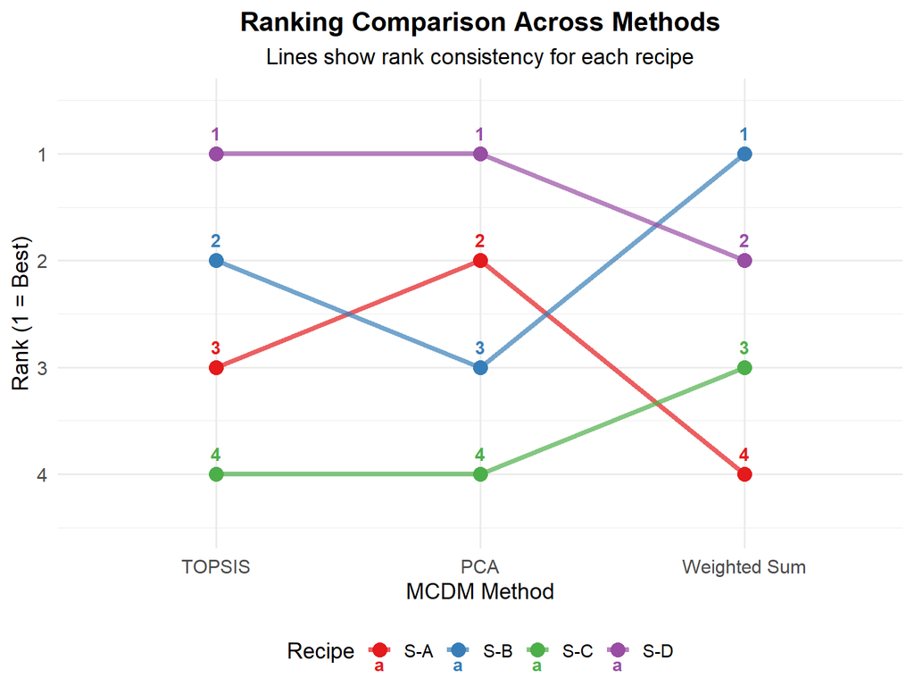

Ranking Comparison Across Methods

```r
# Create ranking comparison plot
ranking_long <- comparison %>%
  select(Recipe, TOPSIS_Rank, PCA_Rank, WS_Rank) %>%
  pivot_longer(cols = -Recipe, names_to = "Method", values_to = "Rank")

# Convert Method names for better display
ranking_long$Method <- factor(ranking_long$Method,
                             levels = c("TOPSIS_Rank", "PCA_Rank", "WS_Rank"),
                             labels = c("TOPSIS", "PCA", "Weighted Sum"))

ggplot(ranking_long, aes(x = Method, y = Rank, color = Recipe, group = Recipe)) +
  geom_line(size = 1.5, alpha = 0.7) +
  geom_point(size = 4) +
  geom_text(aes(label = Rank), vjust = -1, size = 4, fontface = "bold") +
  scale_color_brewer(palette = "Set1") +
  scale_y_reverse(limits = c(4.5, 0.5), breaks = 1:4) +
  labs(x = "MCDM Method", y = "Rank (1 = Best)",
       title = "Ranking Comparison Across Methods",
       subtitle = "Lines show rank consistency for each recipe",
       color = "Recipe") +
  theme_minimal(base_size = 14) +
  theme(plot.title = element_text(face = "bold", hjust = 0.5),
        plot.subtitle = element_text(hjust = 0.5),
        axis.text = element_text(size = 12),
        legend.position = "bottom") +
  annotate("text", x = 1, y = 4.6, label = "Lower rank = Better",
           size = 4, fontface = "italic", color = "gray40")
```

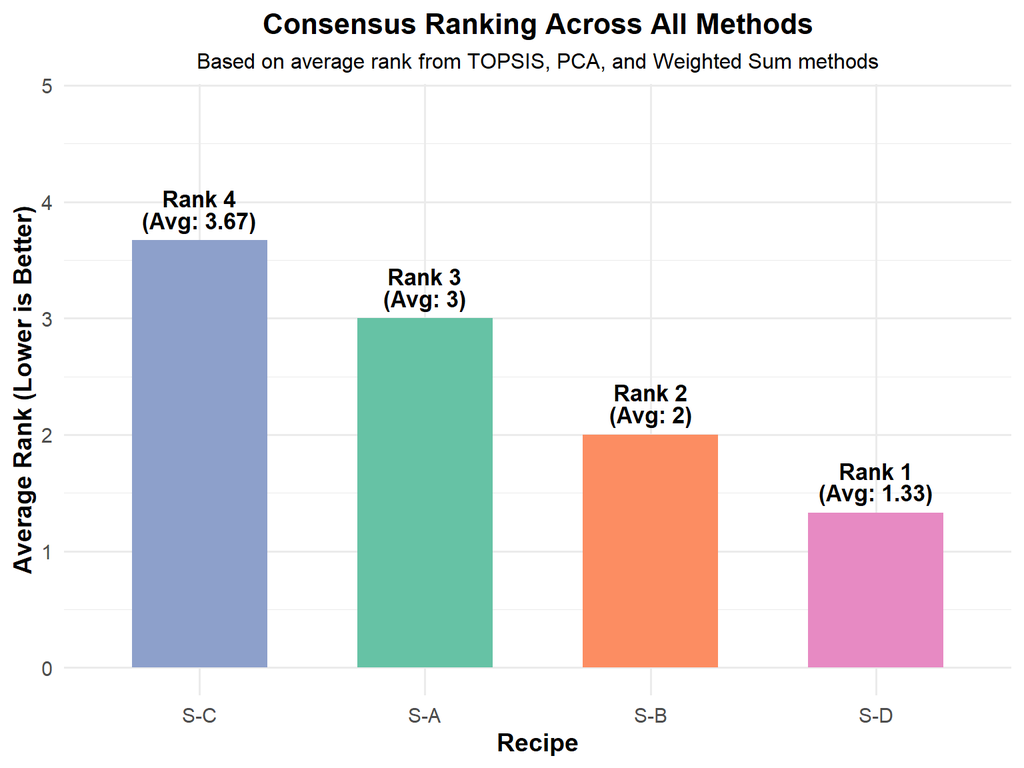

Consensus Ranking Visualization

```r
# Create consensus ranking visualization
consensus_summary <- comparison %>%
  select(Recipe, Average_Rank, Consensus_Rank) %>%
  arrange(Consensus_Rank)

ggplot(consensus_summary, aes(x = reorder(Recipe, -Average_Rank),
                              y = Average_Rank, fill = Recipe)) +
  geom_bar(stat = "identity", width = 0.6) +
  geom_text(aes(label = paste0("Rank ", Consensus_Rank, "\n(Avg: ", Average_Rank, ")")),
            vjust = -0.3, size = 4.5, fontface = "bold", lineheight = 0.8) +
  scale_fill_brewer(palette = "Set2") +
  labs(x = "Recipe", y = "Average Rank (Lower is Better)",
       title = "Consensus Ranking Across All Methods",
       subtitle = "Based on average rank from TOPSIS, PCA, and Weighted Sum methods") +
  theme_minimal(base_size = 14) +
  theme(legend.position = "none",
        plot.title = element_text(face = "bold", hjust = 0.5, size = 16),
        plot.subtitle = element_text(hjust = 0.5, size = 12),
        axis.title = element_text(face = "bold")) +
  ylim(0, max(consensus_summary$Average_Rank) * 1.3)
```

# 7. Discussion and Conclusions

## 7.1 Key Findings

1. **TOPSIS** favored **S-D** for its balanced profile (closest to ideal solution)
2. **PCA** strongly preferred **S-D** for its unique multivariate characteristics
3. **Weighted Sum** selected **S-B** for superior individual nutrient performance

## 7.2 Practical Recommendations

**For general nutritional optimization**: **Recipe S-D** (consensus best)

**For specific applications**:  
- **Balanced overall nutrition**: S-D (first in TOPSIS)  
- **Unique nutritional properties**: S-D (first in PCA)  
- **Individual nutrient maximization**: S-B (first in Weighted Sum)

### 7.3 Limitations and Future Work

- **Equal weights assumption:** Future studies could incorporate expert-derived weights  
- **Small sample size:** Analysis limited to 4 recipes  
- **Sensitivity analysis:** Testing different weight schemes would enhance robustness